# How Does a Bike-Share Navigate Speedy Success?

### ASK: A clear statement of the business task

Cyclistic is a bike-share company located in Chicago. The company features more than 5800 bikes and 600 docking stations. To use the bikes, clients can rent them through three different pricing plans: single-ride passes, full-day passes and annual memberships. Financial analysts of the firm believe that annual memberships are way more profitable than the other plans. Because of this, the marketing department is planning to launch strategies for converting casual riders into annual members. In order to do this, they need to understand how casual riders differ from annual members by analyzing the historical trip data to find trends.

### PREPARE: A description of all data sources used

The data consists of the past 12 months of trip data in csv format, from march 2021 to march 2022. The file for each month contains 13 columns and approximately 300k rows. When joined all bases into one big file, there are more than 6 million of observations. The columns describe the user, the type of bike rented, the type of membership, the time and date of the rent, the stations used and the location of the stations. The data is public and is available under this [license](https://ride.divvybikes.com/data-license-agreement).

### PROCESS: Documentation of any cleaning or manipulation of data

For the cleaning process and manipulation of data, the first task consisted on adding a variable for calculating the ride lenght, which consists on the difference between the time the bike was rented and the time when it was returned. Likewise, the variable day of week was added to better understand the days when casual riders and members use the bikes. After that, observations which resulted in zero or a negative ride lenght were deleted and the same with all rows containing NAs in the column ride lenght. This process gave this comparative summary between databases:

```r
tab <- matrix( c(6094781,13,3385659,5277854,19,739174), ncol = 2, nrow = 3)
colnames(tab) <- c("original_data","modified_data")
rownames(tab) <- c("Observations","Variables","Missing_values")
tab <- as.table (tab)
tab
```

```
##                original_data modified_data
## Observations         6094781       5277854
## Variables                 13            19
## Missing_values       3385659        739174
```

### ANALYZE: A summary of the analysis

The analysis conducted have as objective to undertand the differences between the behavior of casual riders and annual members. To do this, we are going to calculate some statistical indicators that could give a better view of how and when both groups rent bikes. First, we want to know how many rides have been made by members and casual riders during the last year:

```r
tab2 <- matrix( c(2317771,2960083), ncol = 1, nrow = 2)
colnames(tab2) <- c("number_of_rides")
rownames(tab2) <- c("Casual riders","Annual Members")
tab2 <- as.table (tab2)
tab2
```

```
##                number_of_rides
## Casual riders          2317771
## Annual Members         2960083
```

As it can be seen, apporoximately 600k more rides were made by members than by casual riders.

Then we proceed to compare the basic statistics for the ride lenght of both groups:

```r
tab3 <- matrix( c(2019.9,800.9,2019.85/60,800.85/60), ncol = 2, nrow = 2)
colnames(tab3) <- c("Mean_ride_lenght(seconds)","Mean_ride_lenght(minutes)")
rownames(tab3) <- c("Casual riders","Annual Members")
tab3 <- as.table (tab3)
tab3
```

```
##                Mean_ride_lenght(seconds) Mean_ride_lenght(minutes)
## Casual riders                 2019.90000                  33.66417
## Annual Members                 800.90000                  13.34750
```

```r
tab4 <- matrix( c(972,564,972/60,564/60), ncol = 2, nrow = 2)
colnames(tab4) <- c("Median_ride_lenght(seconds)","Median_ride_lenght(minutes)")
rownames(tab4) <- c("Casual riders","Annual Members")
tab4 <- as.table (tab4)
tab4
```

```
##                Median_ride_lenght(seconds) Median_ride_lenght(minutes)
## Casual riders                        972.0                        16.2
## Annual Members                       564.0                         9.4
```

```r
options(scipen = 100, digits = 4)
tab5 <- matrix( c(3356649,93594,3356649/3600,93594/3600), ncol = 2, nrow = 2)
colnames(tab5) <- c("Max_ride_lenght(seconds)","Max_ride_lenght(hours)")
rownames(tab5) <- c("Casual riders","Annual Members")
tab5 <- as.table (tab5)
tab5
```

```
##                Max_ride_lenght(seconds) Max_ride_lenght(hours)
## Casual riders                 3356649.0                  932.4
## Annual Members                  93594.0                   26.0
```

All the statistics presented shows that casual riders tend to ride for longer durations when renting a bike. This is true for the mean, the median and the maximum. Although is evidently that the maximum value of 932 hours (equivalent to 38 days) for the casual riders group is an outlier value, it also sends information about the problems that the company faces when renting bikes. For example, this outlier could have happened because the renter forgot to return the bike or intentionally could have stolen the bike. Likewise, a malfunction of the docking devices could also have been the problem.

Now we want to understand the average duration of a ride among two groups by weekday. This can shows us the days when casual riders and annual members use more or less the bikes.

```r
options(scipen = 100, digits = 4)
tab6 <- matrix( c(2009.07/60,1751.46/60,1763.84/60,1777.96/60,1918.07/60,2170.72/60,2361.02/60,775.71/60,748.48/60,752.24/60,754.84/60,783.70/60,903.44/60,921.82/60), ncol = 2, nrow = 7)
colnames(tab6) <- c("mean_ridelenght_casualriders(minutes)","mean_ridelenght_annualmembers(minutes)")
rownames(tab6) <- c("Monday","Tuesday","Wednesday","Thrusday","Friday","Saturday","Sunday")
tab6 <- as.table (tab6)
tab6
```

```
##           mean_ridelenght_casualriders(minutes)
## Monday                                    33.48
## Tuesday                                   29.19
## Wednesday                                 29.40
## Thrusday                                  29.63
## Friday                                    31.97
## Saturday                                  36.18
## Sunday                                    39.35
##           mean_ridelenght_annualmembers(minutes)
## Monday                                     12.93
## Tuesday                                    12.47
## Wednesday                                  12.54
## Thrusday                                   12.58
## Friday                                     13.06
## Saturday                                   15.06
## Sunday                                     15.36
```

### SHARE: Supporting visualization and key findings

The graphics show in a clear way the difference between the days and duration that casual riders and annual members rent a bike. We first examine the number of rides for each group but specified by weekday:

```r
library(tidyverse)
library(lubridate)
library(ggplot2)
setwd("~/Desktop/Google Analytics Certificate/casestudy_1/csv")
results <- read_csv("results.csv")
```

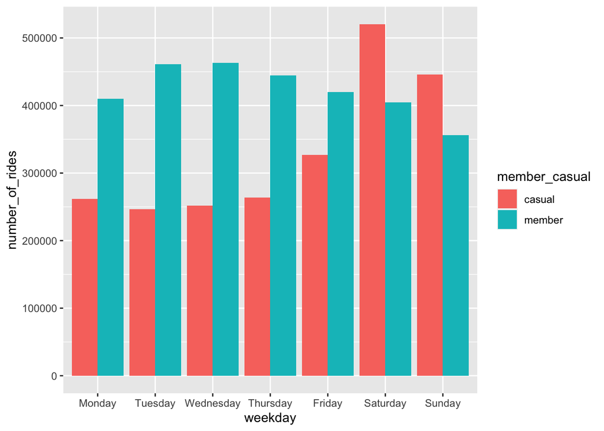

```r
results$weekday <- ordered(results$weekday, levels=c("Monday", "Tuesday", "Wednesday", "Thursday", "Friday", "Saturday","Sunday"))
  ggplot(results, aes(x = weekday, y = number_of_rides, fill = member_casual)) +
  geom_col(position = "dodge")
```

Next, we are going to make a plot of the average time of use that both groups have depending on the day:

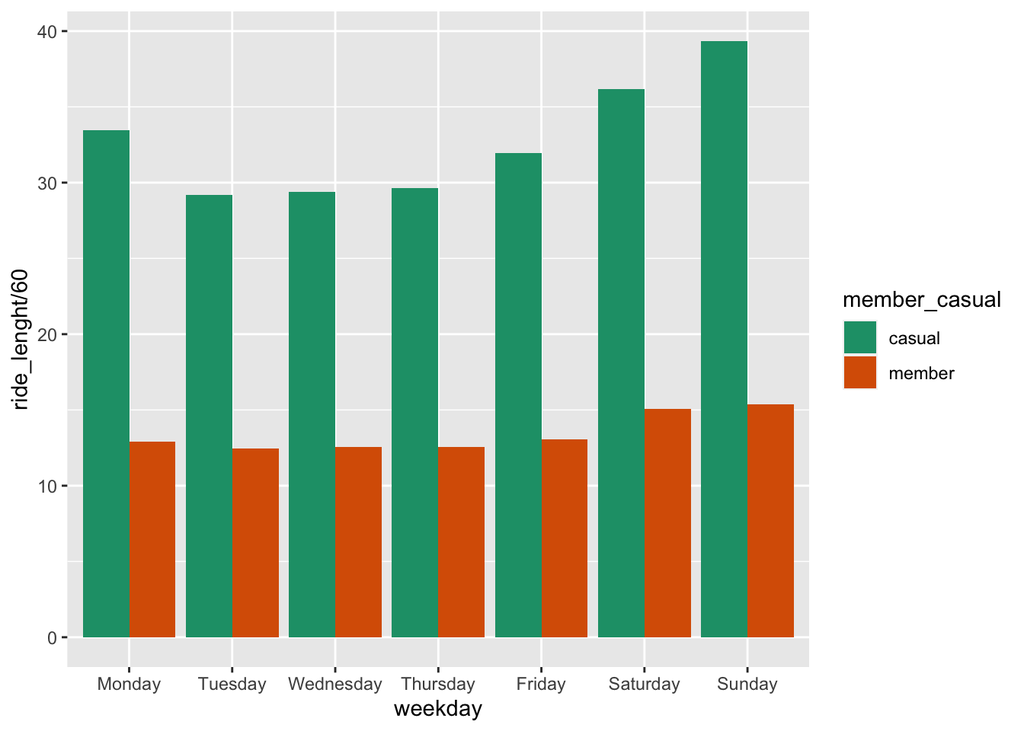

```r
results$weekday <- ordered(results$weekday, levels=c("Monday", "Tuesday", "Wednesday", "Thursday", "Friday", "Saturday","Sunday"))
  ggplot(results, aes(x = weekday, y = ride_lenght/60, fill = member_casual)) +
  geom_col(position = "dodge") +
  scale_fill_brewer(palette="Dark2")
```

*Key findings*:

### ACT: Three recomendatios based on the analysis

- Because casual riders use the bikes more on weekends, this can reflect the fact that they rent bikes like a recreational activity more than as a mean of transport. One way to take advantage of this situation is to target specific online or phisical adds remarking the benefits of using the bike to go to work and making a comparation with conventional urban means of transport (buses, taxi, walking, train, etc). The objective is that consumers choose bikes as a suitable mean to go to work.
- The lenght of ride and frequency of renting a bike are higher on weekends. This can help the digital marketing strategy for posting more and increasing traffic on weekends. Also, the marketing department could give discounts and special offers from Monday to Friday. The objective is to promote the rent of bikes on days when demand is low.
- The results show that annual members use the bikes more frequently but for less time than casual riders. Consequently, casual riders use them less frequently but for longer periods of time. To better understand wheter this difference in time is due to longer distances traveled or intentionally used more time to make exercise, a further spatial analysis is required. The objective would be to identify if such behavior is caused by longer distances traveled and if something about the location of docking stations could be done. Inversely, if bikes are being used for exercising, then the marketing department could also use this information to target even further the scope of the adds.